# Pattern Recognition Assignment - 1

## Name: Arnab Mukherjee Roll No: MB1908

In this assignment we will use python as our programming language to address the problems.

#### Generating Data Set A

We will generate 500 observations each from the trivariate normal distribution with distinct mean vectors as well as distinct dispersion matrices.

```python
import numpy as np
import pandas as pd
import matplotlib.pyplot as plt
```

```python
#for 3D plot
from mpl_toolkits import mplot3d
from mpl_toolkits.mplot3d import Axes3D
plt.rcParams["figure.figsize"] = (30,10)
```

#### Question-1:

Here we will generate the dataset A and create 3D scatter plot for the generated dataset.

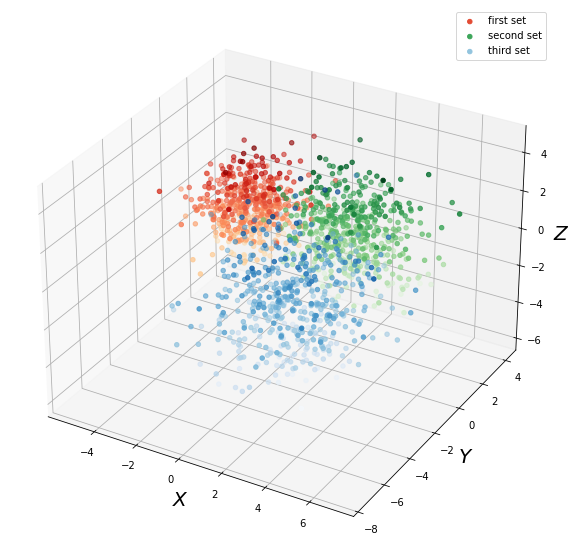

```python
np.random.seed(1908)
ax = plt.axes(projection='3d')
mean1 = [-2,0,1]
mean2 = [2.1,1.3,0]
mean3 = [2,-3.02,-1]
var1 = [[1,0,0],[0,1,0],[0,0,1]]
var2 = [[2,0,0],[0,1,0],[0,0,2]]
var3 = [[3,0,0],[0,3,0],[0,0,3]]
data1_x,data1_y,data1_z = np.random.multivariate_normal(mean1,var1,500).T
data2_x,data2_y,data2_z = np.random.multivariate_normal(mean2,var2,500).T
data3_x,data3_y,data3_z = np.random.multivariate_normal(mean3,var3,500).T
ax.scatter3D(data1_x, data1_y, data1_z, c=data1_z, label = "first set",cmap = "OrRd")
ax.scatter3D(data2_x, data2_y, data2_z, c=data2_z, label ='second set',cmap = "Greens")
ax.scatter3D(data3_x, data3_y, data3_z, c=data3_z, label='third set',cmap = "Blues")
ax.set_xlabel('$X$', fontsize = 20)
ax.set_ylabel('$Y$',fontsize = 20)
ax.set_zlabel('$Z$',fontsize = 20)
ax.legend()
```

Next we convert this dataset to a dataframe for the sake of computational ease. Marker column below will represent the set from which the data comes from. marker values are 0,1,2.

```python
#creating a data frame with these data
np.random.seed(1908)
df = pd.DataFrame(data1_x,columns=["X-axis"])
df_temp = pd.DataFrame(data1_y,columns = ["Y-axis"])
df = pd.concat([df,df_temp],axis = 1)
df_temp = pd.DataFrame(data1_z,columns = ["Z-axis"])
df= pd.concat([df,df_temp],axis = 1)
df_temp = pd.DataFrame(np.zeros(500),columns = ["Marker"])
df_1 = pd.concat([df,df_temp],axis = 1)

df = pd.DataFrame(data2_x,columns=["X-axis"])
df_temp = pd.DataFrame(data2_y,columns = ["Y-axis"])
df = pd.concat([df,df_temp],axis = 1)
df_temp = pd.DataFrame(data2_z,columns = ["Z-axis"])
df= pd.concat([df,df_temp],axis = 1)
df_temp = pd.DataFrame(np.ones(500),columns = ["Marker"])
df_2 = pd.concat([df,df_temp],axis = 1)

df = pd.DataFrame(data3_x,columns=["X-axis"])
df_temp = pd.DataFrame(data3_y,columns = ["Y-axis"])
df = pd.concat([df,df_temp],axis = 1)
df_temp = pd.DataFrame(data3_z,columns = ["Z-axis"])
df= pd.concat([df,df_temp],axis = 1)
df_temp = pd.DataFrame(np.repeat(2,500),columns = ["Marker"])
df_3 = pd.concat([df,df_temp],axis = 1)


df = pd.concat([df_1,df_2,df_3])

s = pd.Series(range(1500))
df.set_index([s])
df = df.sample(frac = 1)
df.head()
```

|  | X-axis | Y-axis | Z-axis | Marker |
| --- | --- | --- | --- | --- |
| 385 | 1.950392 | 2.773708 | -0.280443 | 1.0 |
| 444 | -0.284602 | -0.786112 | 0.954173 | 0.0 |
| 309 | 4.060312 | 1.442383 | 0.305969 | 1.0 |
| 262 | 1.174158 | -5.471219 | 0.515854 | 2.0 |
| 97 | 2.686453 | -3.871344 | -1.980982 | 2.0 |

#### Generating Dataset B

First we import the complete csv leaf data set then we will do the following:

```python
cd "Downloads"
```

```
C:\Users\Arnab\Downloads
```

```python
dfB = pd.read_csv("leaf.csv",header = None)
dfB.head()
```

|  | 0 | 1 | 2 | 3 | 4 | 5 | 6 | 7 | 8 | 9 | 10 | 11 | 12 | 13 | 14 | 15 |
| --- | --- | --- | --- | --- | --- | --- | --- | --- | --- | --- | --- | --- | --- | --- | --- | --- |
| 0 | 1 | 1 | 0.72694 | 1.4742 | 0.32396 | 0.98535 | 1.00000 | 0.83592 | 0.004657 | 0.003947 | 0.047790 | 0.127950 | 0.016108 | 0.005232 | 0.000275 | 1.17560 |
| 1 | 1 | 2 | 0.74173 | 1.5257 | 0.36116 | 0.98152 | 0.99825 | 0.79867 | 0.005242 | 0.005002 | 0.024160 | 0.090476 | 0.008119 | 0.002708 | 0.000075 | 0.69659 |
| 2 | 1 | 3 | 0.76722 | 1.5725 | 0.38998 | 0.97755 | 1.00000 | 0.80812 | 0.007457 | 0.010121 | 0.011897 | 0.057445 | 0.003289 | 0.000921 | 0.000038 | 0.44348 |
| 3 | 1 | 4 | 0.73797 | 1.4597 | 0.35376 | 0.97566 | 1.00000 | 0.81697 | 0.006877 | 0.008607 | 0.015950 | 0.065491 | 0.004271 | 0.001154 | 0.000066 | 0.58785 |
| 4 | 1 | 5 | 0.82301 | 1.7707 | 0.44462 | 0.97698 | 1.00000 | 0.75493 | 0.007428 | 0.010042 | 0.007938 | 0.045339 | 0.002051 | 0.000560 | 0.000024 | 0.34214 |

```python
#Getting unique label values:
dfB[0].unique()
```

```
array([ 1,  2,  3,  4,  5,  6,  7,  8,  9, 10, 11, 12, 13, 14, 15, 22, 23,
       24, 25, 26, 27, 28, 29, 30, 31, 32, 33, 34, 35, 36], dtype=int64)
```

Now interestingly we can see that we have unique values from 1-15 and then from 22-36. So we have to sample from this range and take care of the missing range and make sure that it doesn't hamper our sampling. Essentially we will be performing SRSWOR of size 6 from this set.

```python
import random
unique = dfB[0].unique().tolist() #we want to convert in to a list
s = random.sample(unique, 6)
s
```

```
[30, 5, 32, 7, 28, 15]
```

Now we will select the rows in which the label comes from the set $s$

```python
listB = []
for i in range(len(dfB)):
    if dfB[0][i] in s:
        listB = listB + [i]
len(listB)
```

```
67
```

Now we just select these rows

```python
dfB = dfB.iloc[listB]
dfB.head()
```

|  | 0 | 1 | 2 | 3 | 4 | 5 | 6 | 7 | 8 | 9 | 10 | 11 | 12 | 13 | 14 | 15 |
| --- | --- | --- | --- | --- | --- | --- | --- | --- | --- | --- | --- | --- | --- | --- | --- | --- |
| 40 | 5 | 1 | 0.87844 | 1.8096 | 0.63151 | 0.83923 | 0.83684 | 0.37688 | 0.043563 | 0.34539 | 0.045468 | 0.12554 | 0.015515 | 0.005159 | 0.000228 | 1.1374 |
| 41 | 5 | 2 | 0.88075 | 1.7360 | 0.58345 | 0.83383 | 0.91754 | 0.41551 | 0.040582 | 0.29973 | 0.035786 | 0.10047 | 0.009993 | 0.002759 | 0.000258 | 1.0952 |
| 42 | 5 | 3 | 0.86545 | 1.8803 | 0.62039 | 0.82443 | 0.85439 | 0.33077 | 0.047000 | 0.40204 | 0.039518 | 0.11570 | 0.013210 | 0.004241 | 0.000201 | 1.0136 |
| 43 | 5 | 4 | 0.93671 | 2.4151 | 0.72980 | 0.81793 | 0.86491 | 0.33439 | 0.080539 | 1.18050 | 0.048722 | 0.12051 | 0.014314 | 0.003998 | 0.000372 | 1.3083 |
| 44 | 5 | 5 | 0.92676 | 2.2220 | 0.65580 | 0.82432 | 0.89474 | 0.35618 | 0.038012 | 0.26298 | 0.059981 | 0.14901 | 0.021723 | 0.007525 | 0.000284 | 1.3530 |

Now we select 4 out of 15 features (we have to select the first feature)

```python
l = [1,2,3,4,5,6,7,8,9,10,11,12,13,14,15]
s = random.sample(l,4)
```

```python
s_updated = [0] + s
s_updated
```

```
[0, 9, 7, 6, 14]
```

```python
dfB = dfB.iloc[:,s_updated]
```

```python
dfB.head()
```

|  | 0 | 9 | 7 | 6 | 14 |
| --- | --- | --- | --- | --- | --- |
| 40 | 5 | 0.34539 | 0.37688 | 0.83684 | 0.000228 |
| 41 | 5 | 0.29973 | 0.41551 | 0.91754 | 0.000258 |
| 42 | 5 | 0.40204 | 0.33077 | 0.85439 | 0.000201 |
| 43 | 5 | 1.18050 | 0.33439 | 0.86491 | 0.000372 |
| 44 | 5 | 0.26298 | 0.35618 | 0.89474 | 0.000284 |

So now we have the synthetic dataset , i.e. dataset A as dataframe $df$ and the real dataset , i.e. dataset B as dataframe $dfB$ . An important point to remember in the dataset A the dependent variable is in the Marker column while for dataset B it is in the column $0$

#### Partitioning Dataset into 50% Train and 50% Test

```python
#for Dataset A
np.random.seed(1908)
from sklearn.model_selection import train_test_split
X_train, X_test, y_train, y_test = train_test_split(df.iloc[:,[0,1,2]], df["Marker"].values, test_size=0.50)
```

```python
#for Dataset B
np.random.seed(1908)
XB_train,XB_test,yB_train,yB_test = train_test_split(dfB.iloc[:,[1,2,3,4]], dfB[0].values, test_size=0.50)
```

#### Question-2:

Here we will have to calculate training and test error rates of the Bayes Classifier with respect to the classification problems corresponding to dataset A and dataset B.

#### Bayes Error:

```python
from sklearn.naive_bayes import GaussianNB
gnb = GaussianNB()
```

##### Dataset-A

```python
y_pred = gnb.fit(X_train, y_train).predict(X_test)
tst = ((y_test != y_pred).sum()/750)*100
y_pred_1 = gnb.fit(X_train, y_train).predict(X_train)
tr = ((y_train != y_pred_1).sum()/750)*100
print("Training error rate: " + str(tr) + "%")
print("Test error rate: "+ str(tst) + "%")
```

```
Training error rate: 6.800000000000001%
Test error rate: 6.4%
```

```python
#Confusion matrix for test data
from sklearn.metrics import confusion_matrix
cm = confusion_matrix(y_test, y_pred)
print(cm)
```

```
[[225   9   6]
 [  6 241  10]
 [  7  10 236]]
```

#### Dataset-B

```python
from sklearn.metrics import accuracy_score
y_pred = gnb.fit(XB_train, yB_train).predict(XB_test)
tst = 1- accuracy_score(yB_test, y_pred)
y_pred_1 = gnb.fit(XB_train, yB_train).predict(XB_train)
tr = 1 - accuracy_score(yB_train, y_pred_1)
print("Training error rate: " + str(tr*100) + "%")
print("Test error rate: "+ str(tst*100) + "%")
```

```
Training error rate: 3.0303030303030276%
Test error rate: 41.17647058823529%
```

```python
#Confusion matrix for test data
cm = confusion_matrix(yB_test, y_pred)
print(cm)
```

```
[[3 0 0 0 0 0]
 [0 6 0 1 0 0]
 [2 0 4 0 0 0]
 [0 0 0 5 0 1]
 [0 1 0 9 0 0]
 [0 0 0 0 0 2]]
```

#### Question-3

##### Linear Discriminant Analysis

##### Dataset-A

```python
from sklearn.preprocessing import StandardScaler
sc = StandardScaler()
X_train = sc.fit_transform(X_train)
X_test = sc.transform(X_test)
from sklearn.discriminant_analysis import LinearDiscriminantAnalysis as LDA

lda = LDA(n_components=2)
lda.fit(X_train,y_train)
y_pred = lda.predict(X_test)
tst = 1 - accuracy_score(y_test, y_pred)
y_pred_1 = lda.predict(X_train)
tr = 1 - accuracy_score(y_train, y_pred_1)
print("Training error rate: " + str(tr*100) + "%")
print("Test error rate: "+ str(tst*100) + "%")
```

```
Training error rate: 7.733333333333336%
Test error rate: 6.799999999999995%
```

```python
#Confusion matrix for test data
cm = confusion_matrix(y_test, y_pred)
print(cm)
```

```
[[233   5   2]
 [ 10 243   4]
 [ 13  17 223]]
```

##### Dataset-B

```python
XB_train = sc.fit_transform(XB_train)
XB_test = sc.transform(XB_test)
lda = LDA(n_components=3)
lda.fit(XB_train,yB_train)
y_pred = lda.predict(XB_test)
tst = 1 - accuracy_score(yB_test, y_pred)
y_pred_1 = lda.predict(XB_train)
tr = 1 - accuracy_score(yB_train, y_pred_1)
print("Training error rate: " + str(tr*100) + "%")
print("Test error rate: "+ str(tst*100) + "%")
```

```
Training error rate: 12.121212121212121%
Test error rate: 52.94117647058824%
```

```python
#Confusion matrix for test data
cm = confusion_matrix(yB_test, y_pred)
print(cm)
```

```
[[3 0 0 0 0 0]
 [0 3 0 0 0 4]
 [1 0 5 0 0 0]
 [0 1 0 1 3 1]
 [0 0 0 6 2 2]
 [0 0 0 0 0 2]]
```

#### Quadratic Discriminant Analysis

##### Dataset-A

```python
from sklearn.discriminant_analysis import QuadraticDiscriminantAnalysis as QDA
clf = QDA()
clf.fit(X_train, y_train)
QDA(priors=None, reg_param=0.0)
y_pred = clf.predict(X_test)
tst = 1 - accuracy_score(y_test, y_pred)
y_pred_1 = clf.predict(X_train)
tr = 1 - accuracy_score(y_train, y_pred_1)
print("Training error rate: " + str(tr*100) + "%")
print("Test error rate: "+ str(tst*100) + "%")
```

```
Training error rate: 6.933333333333335%
Test error rate: 6.266666666666665%
```

```python
#Confusion matrix for test data
cm = confusion_matrix(y_test, y_pred)
print(cm)
```

```
[[225  10   5]
 [  5 243   9]
 [  7  11 235]]
```

##### Dataset-B

```python
clf = QDA()
clf.fit(XB_train, yB_train)
QDA(priors=None, reg_param=0.0)
y_pred = clf.predict(XB_test)
tst = 1 - accuracy_score(yB_test, y_pred)
y_pred_1 = clf.predict(XB_train)
tr = 1 - accuracy_score(yB_train, y_pred_1)
print("Training error rate: " + str(tr*100) + "%")
print("Test error rate: "+ str(tst*100) + "%")
```

```
Training error rate: 0.0%
Test error rate: 70.58823529411764%
```

```python
#Confusion matrix for test data
cm = confusion_matrix(yB_test, y_pred)
print(cm)
```

```
[[ 3  0  0  0  0  0]
 [ 5  0  0  2  0  0]
 [ 6  0  0  0  0  0]
 [ 1  0  0  5  0  0]
 [ 0  0  0 10  0  0]
 [ 0  0  0  0  0  2]]
```

#### Support Vector Machine - one vs one

We will use linear kernel, polynomial kernel and gaussian kernel

##### Dataset-A

```python
from sklearn.svm import SVC
```

```python
#Linear Kernel
linear_svc1 = SVC(
    C=10000, kernel='linear'
).fit(X_train, y_train)
y_pred = linear_svc1.predict(X_test)
tst = 1 - accuracy_score(y_test, y_pred)
y_pred_1 = linear_svc1.predict(X_train)
tr = 1 - accuracy_score(y_train, y_pred_1)
print("Training error rate: " + str(tr*100) + "%")
print("Test error rate: "+ str(tst*100) + "%")
cm = confusion_matrix(y_test, y_pred)
print(cm)
```

```
Training error rate: 7.733333333333336%
Test error rate: 6.266666666666665%
[[227   7   6]
 [  3 246   8]
 [ 10  13 230]]
```

```python
#Ploynomial Kernel
poly_svc1 = SVC(
    C=10, kernel='poly', degree=4, coef0=7
).fit(X_train, y_train)
y_pred = poly_svc1.predict(X_test)
tst = 1 - accuracy_score(y_test, y_pred)
y_pred_1 = poly_svc1.predict(X_train)
tr = 1 - accuracy_score(y_train, y_pred_1)
print("Training error rate: " + str(tr*100) + "%")
print("Test error rate: "+ str(tst*100) + "%")
cm = confusion_matrix(y_test, y_pred)
print(cm)
```

```
Training error rate: 5.466666666666664%
Test error rate: 6.799999999999995%
[[223   9   8]
 [  6 246   5]
 [ 11  12 230]]
```

```python
#Gaussian Kernel
rbf_svc1 = SVC(
    kernel='rbf', gamma=1
).fit(X_train, y_train)
y_pred = rbf_svc1.predict(X_test)
tst = 1 - accuracy_score(y_test, y_pred)
y_pred_1 = rbf_svc1.predict(X_train)
tr = 1 - accuracy_score(y_train, y_pred_1)
print("Training error rate: " + str(tr*100) + "%")
print("Test error rate: "+ str(tst*100) + "%")
cm = confusion_matrix(y_test, y_pred)
print(cm)
```

```
Training error rate: 5.8666666666666645%
Test error rate: 5.733333333333334%
[[226   9   5]
 [  4 250   3]
 [  7  15 231]]
```

##### Dataset-B

```python
#Linear Kernel
linear_svc1 = SVC(
    C=10000, kernel='linear'
).fit(XB_train, yB_train)
y_pred = linear_svc1.predict(XB_test)
tst = 1 - accuracy_score(yB_test, y_pred)
y_pred_1 = linear_svc1.predict(XB_train)
tr = 1 - accuracy_score(yB_train, y_pred_1)
print("Training error rate: " + str(tr*100) + "%")
print("Test error rate: "+ str(tst*100) + "%")
cm = confusion_matrix(yB_test, y_pred)
print(cm)
```

```
Training error rate: 0.0%
Test error rate: 32.35294117647059%
[[3 0 0 0 0 0]
 [0 6 0 0 0 1]
 [1 0 5 0 0 0]
 [0 1 0 2 3 0]
 [0 2 0 2 6 0]
 [0 1 0 0 0 1]]
```

```python
#Ploynomial Kernel
poly_svc1 = SVC(
    C=10, kernel='poly', degree=4, coef0=7
).fit(XB_train, yB_train)
y_pred = poly_svc1.predict(XB_test)
tst = 1 - accuracy_score(yB_test, y_pred)
y_pred_1 = poly_svc1.predict(XB_train)
tr = 1 - accuracy_score(yB_train, y_pred_1)
print("Training error rate: " + str(tr*100) + "%")
print("Test error rate: "+ str(tst*100) + "%")
cm = confusion_matrix(yB_test, y_pred)
print(cm)
```

```
Training error rate: 0.0%
Test error rate: 35.29411764705882%
[[3 0 0 0 0 0]
 [0 6 0 0 0 1]
 [1 0 5 0 0 0]
 [0 1 0 1 3 1]
 [0 2 0 2 6 0]
 [0 1 0 0 0 1]]
```

```python
#Gaussian Kernel
rbf_svc1 = SVC(
    kernel='rbf', gamma=1
).fit(XB_train, yB_train)
y_pred = rbf_svc1.predict(XB_test)
tst = 1 - accuracy_score(yB_test, y_pred)
y_pred_1 = rbf_svc1.predict(XB_train)
tr = 1 - accuracy_score(yB_train, y_pred_1)
print("Training error rate: " + str(tr*100) + "%")
print("Test error rate: "+ str(tst*100) + "%")
cm = confusion_matrix(yB_test, y_pred)
print(cm)
```

```
Training error rate: 12.121212121212121%
Test error rate: 58.82352941176471%
[[3 0 0 0 0 0]
 [0 2 0 0 0 5]
 [3 0 3 0 0 0]
 [0 0 0 4 0 2]
 [3 0 0 5 0 2]
 [0 0 0 0 0 2]]
```

#### Support Vector Machine: one vs many

##### Dataset-A

```python
from sklearn.multiclass import OneVsRestClassifier
clf = OneVsRestClassifier(SVC()).fit(X_train, y_train)
y_pred = clf.predict(X_test)
y_pred = clf.predict(X_test)
tst = 1 - accuracy_score(y_test, y_pred)
y_pred_1 = clf.predict(X_train)
tr = 1 - accuracy_score(y_train, y_pred_1)
print("Training error rate: " + str(tr*100) + "%")
print("Test error rate: "+ str(tst*100) + "%")
cm = confusion_matrix(y_test, y_pred)
print(cm)
```

```
Training error rate: 6.266666666666665%
Test error rate: 6.000000000000005%
[[228   9   3]
 [  3 248   6]
 [  7  17 229]]
```

##### Dataset-B

```python
clf = OneVsRestClassifier(SVC()).fit(XB_train, yB_train)
y_pred = clf.predict(XB_test)
y_pred = clf.predict(XB_test)
tst = 1 - accuracy_score(yB_test, y_pred)
y_pred_1 = clf.predict(XB_train)
tr = 1 - accuracy_score(yB_train, y_pred_1)
print("Training error rate: " + str(tr*100) + "%")
print("Test error rate: "+ str(tst*100) + "%")
cm = confusion_matrix(yB_test, y_pred)
print(cm)
```

```
Training error rate: 18.181818181818176%
Test error rate: 55.88235294117647%
[[3 0 0 0 0 0]
 [0 1 0 0 0 6]
 [0 0 6 0 0 0]
 [0 0 0 3 0 3]
 [0 0 0 7 0 3]
 [0 0 0 0 0 2]]
```

#### K-Nearest Neighbour Classification with K=1

##### Dataset-A

```python
from sklearn.neighbors import KNeighborsClassifier
classifier = KNeighborsClassifier(n_neighbors=1)
classifier.fit(X_train, y_train)
y_pred = classifier.predict(X_test)
tst = 1 - accuracy_score(y_test, y_pred)
y_pred_1 = classifier.predict(X_train)
tr = 1 - accuracy_score(y_train, y_pred_1)
print("Training error rate: " + str(tr*100) + "%")
print("Test error rate: "+ str(tst*100) + "%")
cm = confusion_matrix(y_test, y_pred)
print(cm)
```

```
Training error rate: 0.0%
Test error rate: 10.533333333333328%
[[217  11  12]
 [ 11 224  22]
 [  6  17 230]]
```

##### Dataset-B

```python
classifier = KNeighborsClassifier(n_neighbors=1)
classifier.fit(XB_train, yB_train)
y_pred = classifier.predict(XB_test)
tst = 1 - accuracy_score(yB_test, y_pred)
y_pred_1 = classifier.predict(XB_train)
tr = 1 - accuracy_score(yB_train, y_pred_1)
print("Training error rate: " + str(tr*100) + "%")
print("Test error rate: "+ str(tst*100) + "%")
cm = confusion_matrix(yB_test, y_pred)
print(cm)
```

```
Training error rate: 0.0%
Test error rate: 64.70588235294117%
[[3 0 0 0 0 0]
 [0 3 0 0 0 4]
 [4 0 2 0 0 0]
 [0 0 0 2 2 2]
 [0 1 0 8 0 1]
 [0 0 0 0 0 2]]
```

#### K-Nearest Neighbour Classification with K=3

##### Dataset-A

```python
from sklearn.neighbors import KNeighborsClassifier
classifier = KNeighborsClassifier(n_neighbors=3)
classifier.fit(X_train, y_train)
y_pred = classifier.predict(X_test)
tst = 1 - accuracy_score(y_test, y_pred)
y_pred_1 = classifier.predict(X_train)
tr = 1 - accuracy_score(y_train, y_pred_1)
print("Training error rate: " + str(tr*100) + "%")
print("Test error rate: "+ str(tst*100) + "%")
cm = confusion_matrix(y_test, y_pred)
print(cm)
```

```
Training error rate: 5.333333333333334%
Test error rate: 7.333333333333336%
[[224   9   7]
 [ 10 240   7]
 [  6  16 231]]
```

##### Dataset-B

```python
classifier = KNeighborsClassifier(n_neighbors=3)
classifier.fit(XB_train, yB_train)
y_pred = classifier.predict(XB_test)
tst = 1 - accuracy_score(yB_test, y_pred)
y_pred_1 = classifier.predict(XB_train)
tr = 1 - accuracy_score(yB_train, y_pred_1)
print("Training error rate: " + str(tr*100) + "%")
print("Test error rate: "+ str(tst*100) + "%")
cm = confusion_matrix(yB_test, y_pred)
print(cm)
```

```
Training error rate: 21.212121212121215%
Test error rate: 55.88235294117647%
[[3 0 0 0 0 0]
 [1 1 0 0 0 5]
 [0 0 6 0 0 0]
 [0 0 0 1 3 2]
 [0 0 0 6 2 2]
 [0 0 0 0 0 2]]
```

#### Question-4:

In this question we have to use multiedit and condensation method. Now unfortunately there aren't any packages in python that have functions which can perform these tasks. For this reason I wrote the function for multiedit and condensation on my own. I will use it here. Note that both the functions returns dataframe for X and array for y.

```python
#Function to perform multiediting, with N = 3 partitions and I = 5 and assuming the dataset is already shuffled
from sklearn.neighbors import KNeighborsClassifier
classifier = KNeighborsClassifier(n_neighbors=1) #Because we are working with 1-NNR
def multiedit(X,y):
    df1 = X[:250]
    y1 = y[:250]
    df2 = X[250:500]
    y2 = y[250:500]
    df3 = X[500:]
    y3 = y[500:]
    I = 1
    count = len(X)
    print("Number of samples = " + str(count))
    while(I<5):
        #Reindexing phase
        df1.index = pd.RangeIndex(len(df1.index))
        df1.index = range(len(df1.index))
        df2.index = pd.RangeIndex(len(df2.index))
        df2.index = range(len(df2.index))
        df3.index = pd.RangeIndex(len(df3.index))
        df3.index = range(len(df3.index))
        #For partition-1 we test it using knn for partition-2
        classifier.fit(df2, y2)
        y_pred = classifier.predict(df1)
        list1 = []
        for i in range(len(df1)):
            if y_pred[i] != y1[i]:
                list1.append(i)
        #For partition-2 we test it using knn for partition-3
        classifier.fit(df3, y3)
        y_pred = classifier.predict(df2)
        list2 = []
        for i in range(len(df2)):
            if y_pred[i] != y2[i]:
                list2.append(i)
        #For partition-3 we test it using knn for partition-1
        classifier.fit(df1, y1)
        y_pred = classifier.predict(df3)
        list3 = []
        for i in range(len(df3)):
            if y_pred[i] != y3[i]:
                list3.append(i)
        #discarding misclassified samples
        df1 = df1.drop(list1)
        y1 = [i for j, i in enumerate(y1) if j not in list1]
        df2 = df2.drop(list2)
        y2 = [i for j, i in enumerate(y2) if j not in list2]
        df3 = df3.drop(index = list3)
        y3 = [i for j, i in enumerate(y3) if j not in list3]

        temp = len(df1) + len(df2) + len(df3)
        if count == temp:
            I = I+1
        else:
            I = 1
        count = temp
        print("Number of samples = " + str(count))
    df = pd.concat([df1,df2,df3],axis = 0)
    y_new = y1 + y2 + y3
    return df,y_new
```

```python
#Function for the Basuc condensed NN (CNN) Rule
classifier = KNeighborsClassifier(n_neighbors=1)
def cnn(X,y):
    df1 = X[:2]
    y1 = y[:2]
    df2 = X[2:]
    y2 = y[2:]
    count = 1
    df1.index = pd.RangeIndex(len(df1.index))
    df1.index = range(len(df1.index))
    df2.index = pd.RangeIndex(len(df2.index))
    df2.index = range(len(df2.index))
    while count!=0 and len(y2)!=0:
        df1.index = pd.RangeIndex(len(df1.index))
        df1.index = range(len(df1.index))
        df2.index = pd.RangeIndex(len(df2.index))
        df2.index = range(len(df2.index))
        classifier.fit(df1,y1)
        y_pred = classifier.predict(df2)
        list1 = []
        for i in range(len(df2)):
            if y_pred[i] != y2[i]:
                list1.append(i)
        count = len(list1)
        df_temp = df2.iloc[list1]
        df1 = pd.concat([df1,df_temp],axis = 0)
        df2 = df2.drop(list1)
        temp = []
        for i in range(len(y2)):
            if i in list1:
                y1 = np.append(y1,y2[i])
            else:
                temp.append(y2[i])
        y2 = temp.copy()
        print("Number of misclassified points = "+ str(count))
    return df1,y1
```

#### Applying MultiEdit and then performing 1-NNR

```python
X = df.iloc[:750,[0,1,2]]# 50% training set
X.head()
```

|  | X-axis | Y-axis | Z-axis |
| --- | --- | --- | --- |
| 385 | 1.950392 | 2.773708 | -0.280443 |
| 444 | -0.284602 | -0.786112 | 0.954173 |
| 309 | 4.060312 | 1.442383 | 0.305969 |
| 262 | 1.174158 | -5.471219 | 0.515854 |
| 97 | 2.686453 | -3.871344 | -1.980982 |

```python
y = df["Marker"].values[:750]
```

```python
df_test = df.iloc[750:,[0,1,2]]# 50% test set
y_test = df["Marker"].values[750:]
```

```python
df_new,y_new = multiedit(X,y)
```

```
Number of samples = 750
Number of samples = 677
Number of samples = 670
Number of samples = 670
Number of samples = 670
Number of samples = 670
Number of samples = 670
```

```python
classifier = KNeighborsClassifier(n_neighbors=1)
classifier.fit(df_new, y_new)
y_pred = classifier.predict(df_test)
tst = 1 - accuracy_score(y_test, y_pred)
y_pred_1 = classifier.predict(df_new)
tr = 1 - accuracy_score(y_new, y_pred_1)
print("Training error rate: " + str(tr*100) + "%")
print("Test error rate: "+ str(tst*100) + "%")
cm = confusion_matrix(y_test, y_pred)
print(cm)
```

```
Training error rate: 0.0%
Test error rate: 6.399999999999995%
[[226   6   4]
 [  6 246   6]
 [  8  18 230]]
```

##### Applying Condensation and 1-NNR

```python
df_new , y_new = cnn(X,y)
classifier = KNeighborsClassifier(n_neighbors=1)
classifier.fit(df_new, y_new)
y_pred = classifier.predict(df_test)
tst = 1 - accuracy_score(y_test, y_pred)
y_pred_1 = classifier.predict(df_new)
tr = 1 - accuracy_score(y_new, y_pred_1)
print("Training error rate: " + str(tr*100) + "%")
print("Test error rate: "+ str(tst*100) + "%")
cm = confusion_matrix(y_test, y_pred)
print(cm)
```

```
Number of misclassified points = 304
Number of misclassified points = 370
Number of misclassified points = 2
Number of misclassified points = 0
Training error rate: 0.0%
Test error rate: 9.733333333333338%
[[219  12   5]
 [ 10 228  20]
 [ 11  15 230]]
```

##### Applying MultiEdit and Condensation and then 1-NNR

```python
df_new,y_new = multiedit(X,y)
df_new , y_new = cnn(df_new,y_new)
classifier = KNeighborsClassifier(n_neighbors=1)
classifier.fit(df_new, y_new)
y_pred = classifier.predict(df_test)
tst = 1 - accuracy_score(y_test, y_pred)
y_pred_1 = classifier.predict(df_new)
tr = 1 - accuracy_score(y_new, y_pred_1)
print("Training error rate: " + str(tr*100) + "%")
print("Test error rate: "+ str(tst*100) + "%")
cm = confusion_matrix(y_test, y_pred)
print(cm)
```

```
Number of samples = 750
Number of samples = 677
Number of samples = 670
Number of samples = 670
Number of samples = 670
Number of samples = 670
Number of samples = 670
Number of misclassified points = 254
Number of misclassified points = 137
Number of misclassified points = 7
Number of misclassified points = 0
Training error rate: 0.0%
Test error rate: 6.533333333333335%
[[225   7   4]
 [  5 246   7]
 [  8  18 230]]
```

### Comparison Tables:

#### Dataset-A

| Name | Train Error | Test Error |
| --- | --- | --- |
| Bayes(Naive) | 6.8 | 6.4 |
| LDA | 7.733 | 6.7999 |
| QDA | 6.933 | 6.266 |
| SVM one v one Kernel = linear | 7.733 | 6.266 |
| SVM one v one Kernel = polynomial | 5.466 | 6.7999 |
| SVM one v one Kernel = gaussian | 5.866 | 5.7333 |
| SVM one v many | 6.2666 | 6.0000 |
| KNN K=1 | 0.0 | 10.5333 |
| KNN K=3 | 5.33 | 7.333 |
| MultiEdit - 1NNR | 0.0 | 6.399 |
| Condensation-1NNR | 0.0 | 9.733 |
| MultiEdit-Condensation-1NNR | 0.0 | 6.5333 |

##### As we can see from the above table that one v one svm with gaussian kernel is the best fit for this dataset. While it might strike surprising that the error rate is lower than bayes error rate but we have to remember that we are not evaluating the actual bayes error rate here , rather we are evaluating the naive bayes with normal probability model.

#### Dataset-B

[output not shown]

##### Note that here typically the training error is very low and test error is extremely high this is primarily due to the fact that the data set is so small. In this setup SVM one v one with linear kernel performs best but still there is clear indication of over-fitting. Same logic as the previous explanation applies for naive bayes here as well. (i.e. it is not the true bayes error rate). So clearly in this particular setup we need more data before we can conclude anything.